### Notas de aula de Mecânica Quântica Autor: Jonas Maziero

# Potencial poço quadrado infinito

Esse é um dois exemplos de potenciais mais simples, e por isso é bastante utilizado em exemplos e exercícios.

O potencial de um quanton em uma caixa unidimensional é \begin{cases} U(x<0)=\infty, \\ U(0<x<a) = 0, \\ U(x>a) = \infty. \end{cases} Nesse caso, queremos obter soluções para a equação de Schrödinger independente do tempo unidimensional (EqSIT1D): \begin{equation} -\frac{\hbar^{2}}{2m}\partial_{xx}\Xi(x)+U(x)\Xi(x)=E\Xi(x). \end{equation}

À esquerda e à direita do poço, como o quanton não pode ter energia infinita, devemos ter \begin{equation} \Xi_{e}(x<0)=\Xi_{d}(x>a)=0. \end{equation} Dentro do poço, $0<x<a$, a EqSIT1D fica \begin{equation} -\frac{\hbar^{2}}{2m}\partial_{xx}\Xi(x)+0\Xi(x)=E\Xi(x) \therefore \partial_{xx}\Xi(x)+k_{i}^{2}\Xi(x)=0, \end{equation} com \begin{equation} k_{i} = \frac{\sqrt{2mE}}{\hbar}. \end{equation} As soluções no interior do poço tem a forma geral \begin{equation} \Xi_{i}(0<x<a) = c_{id}e^{ik_{i}x} + c_{ie}e^{-ik_{i}x}. \end{equation}

## Quantização da energia

Na sequência, vamos determinar os coeficientes. Começamos impondo a continuidade da função de onda: \begin{align} & \Xi_{e}(x=0)=0=\Xi_{i}(x=0) \therefore c_{id}+c_{ie}=0 \therefore c_{id}=-c_{ie}, \\ & \Xi_{i}(x=a)=\Xi_{d}(x=a)=0 \therefore c_{id}e^{ik_{i}a}+c_{ie}e^{-ik_{i}a} = 0. \end{align} Juntando esses resultados, teremos \begin{align} & c_{id}e^{ik_{i}a}-c_{id}e^{-ik_{i}a} = c_{id}\left(e^{ik_{i}a}-e^{-ik_{i}a}\right) = c_{id}2i\sin(k_{i}a)= 0, \\ & \therefore k_{i}a=n\pi \text{ com } n=1,2,3,\cdots. \end{align} Portanto o número de onda, e com isso o comprimento de onda de de Broglie, é quantizado: \begin{equation} k_{i} = \frac{n\pi}{a}\text{, com }n\in\mathbb{Z}_{>0}. \end{equation} Por conseguinte, a energia também é quantizada \begin{equation} E_{n} = \frac{\hbar^{2}k_{i}^{2}}{2m} = \left(\frac{\hbar^{2}\pi^{2}}{2ma^{2}}\right)n^{2}\text{, com }n\in\mathbb{N}. \end{equation} Vale observar que $n$ é chamado de **número quântico**.

Observamos que, além de ter energia quantizada, o quanton, indo de acordo com o princípio de indeterminação de Heisenberg, não pode ter energia nula ($X$ e $P$ não podem ter valores bem difinidos simultaneamente). O quanton tem que ter uma energia mínima, a *energia de ponto zero* obtida com $n=1$: \begin{equation} E_{1} = \frac{\hbar^{2}\pi^{2}}{2ma^{2}}>0. \end{equation} Na figura abaixo está mostrado o diagrama de energia para o poço quadrado infinito.

```python
me = 9.109382*10**-31 # kg (massa do elétron)
e = 1.60217662*10**-19 # C (carga elementar)
h = 6.626069*10**-34 # Js (constante de Planck)
heV = h/e # em eV
import math
hb = h/(2*math.pi) # hbar
c = 2.99792458*10**8 # m/s (velocidade da luz no vácuo)
import matplotlib
from matplotlib import pyplot as plt
import numpy as np
```

```
m = 9.109382e-31kg em um poço infinito de largura 1e-09m
```

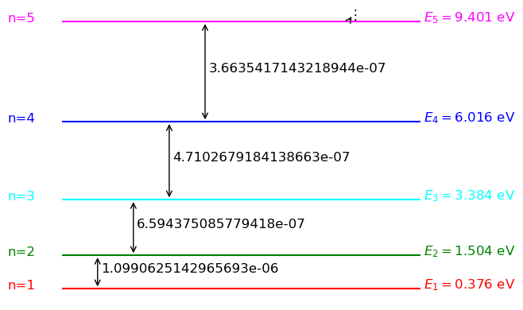

```python
def poco_E(n,m,a):
    return (((hb*math.pi*n)**2)/(2*m*a**2))/e # em eV
def poco_oo_niveis(xmin,xmax,m,a):
    matplotlib.rcParams.update({'font.size':12})
    plt.hlines(poco_E(1,m,a),xmin,xmax,color='red')
    plt.text(-0.15,poco_E(1,m,a),'n=1',color='red')
    plt.text(1.01,poco_E(1,m,a),r'$E_{1}=$'\
             +str('%3.3f'%(poco_E(1,m,a))+' eV'),color='red')
    plt.hlines(poco_E(2,m,a),xmin,xmax,color='green')
    plt.text(-0.15,poco_E(2,m,a),'n=2',color='green')
    plt.text(1.01,poco_E(2,m,a),r'$E_{2}=$'\
             +str('%3.3f'%(poco_E(2,m,a))+' eV'),color='green')
    plt.hlines(poco_E(3,m,a),xmin,xmax,color='cyan')
    plt.text(-0.15,poco_E(3,m,a),'n=3',color='cyan')
    plt.text(1.01,poco_E(3,m,a),r'$E_{3}=$'\
             +str('%3.3f'%(poco_E(3,m,a))+' eV'),color='cyan')
    plt.hlines(poco_E(4,m,a),xmin,xmax,color='blue')
    plt.text(-0.15,poco_E(4,m,a),'n=4',color='blue')
    plt.text(1.01,poco_E(4,m,a),r'$E_{4}=$'\
             +str('%3.3f'%(poco_E(4,m,a))+' eV'),color='blue')
    plt.hlines(poco_E(5,m,a),xmin,xmax,color='magenta')
    plt.text(-0.15,poco_E(5,m,a),'n=5',color='magenta')
    plt.text(1.01,poco_E(5,m,a),r'$E_{5}=$'\
             +str('%3.3f'%(poco_E(5,m,a))+' eV'),color='magenta')
    plt.annotate("", xy=(0.1,poco_E(1,m,a)),
                 xytext=(0.1,poco_E(2,m,a)),
                 arrowprops=dict(arrowstyle="<->"))
    plt.text(0.11,(poco_E(1,m,a)+poco_E(2,m,a))/2,
             (c*heV)/(poco_E(2,m,a)-poco_E(1,m,a)))
    plt.annotate("", xy=(0.2,poco_E(2,m,a)),
                 xytext=(0.2,poco_E(3,m,a)),
                 arrowprops=dict(arrowstyle="<->"))
    plt.text(0.21,(poco_E(2,m,a)+poco_E(3,m,a))/2,
             (c*heV)/(poco_E(3,m,a)-poco_E(2,m,a)))
    plt.annotate("", xy=(0.3,poco_E(3,m,a)),
                 xytext=(0.3,poco_E(4,m,a)),
                 arrowprops=dict(arrowstyle="<->"))
    plt.text(0.31,(poco_E(3,m,a)+poco_E(4,m,a))/2,
             (c*heV)/(poco_E(4,m,a)-poco_E(3,m,a)))
    plt.annotate("", xy=(0.4,poco_E(4,m,a)),
                 xytext=(0.4,poco_E(5,m,a)),
                 arrowprops=dict(arrowstyle="<->"))
    plt.text(0.41,(poco_E(4,m,a)+poco_E(5,m,a))/2,
             (c*heV)/(poco_E(5,m,a)-poco_E(4,m,a)))
    plt.annotate(r"$\vdots$", xy=(0.8,poco_E(5,m,a)),
                 xytext=(0.8,poco_E(5,m,a)+0.1),
                 arrowprops=dict(arrowstyle="<-"))
    plt.axis('off')
    plt.show()
a = 10**-9; m = me;
print('m = '+str(m)+'kg em um poço infinito de largura '+str(a)+'m')
poco_oo_niveis(0,1,m,a)
```

## Função de onda

Usando $c_{id}=-c_{ie}$ obtemos \begin{align} \Xi_{i}(0<x<a) & = c_{id}\left(e^{ik_{i}x}-e^{ik_{i}x}\right) = 2ic_{id}\sin(k_{i}x) \\ & =: C_{i}\sin\left(\frac{n\pi x}{a}\right). \end{align} Para determinar a constante que falta, usamos a normalização da função de onda: \begin{align} 1 & = \int_{-\infty}^{\infty}|\Xi(x)|^{2}dx \\ & = \int_{-\infty}^{0}|\Xi_{e}(x<0)|^{2}dx + \int_{0}^{a}|\Xi_{i}(0<x<a)|^{2}dx + \int_{a}^{\infty}|\Xi_{d}(x>a)|^{2}dx \\ & = 0 + \int_{0}^{a}|C_{i}|^{2}\sin^{2}\left(\frac{n\pi x}{a}\right)dx + 0 \\ & = |C_{i}|^{2}\int_{0}^{a}\left(\frac{1}{2}-\frac{1}{2}\cos\left(\frac{2n\pi x}{a}\right)\right)dx \\ & = |C_{i}|^{2}\left(\frac{a}{2}-\frac{a}{2n\pi}\left(\sin\left(\frac{2n\pi x}{a}\right)\right)_{0}^{a}\right) \\ & = |C_{i}|^{2}\left(\frac{a}{2}-\frac{a}{2n\pi}\left(\sin\left(\frac{2n\pi a}{a}\right)-\sin(0)\right)\right) \\ & = |C_{i}|^{2}\left(\frac{a}{2}-0\right). \end{align} Então $|C_{i}| = \sqrt{2/a}$, $C_{i}=|C_{i}|e^{i\phi}$ e assim \begin{equation} \Xi_{i}(0<x<a) = e^{i\phi}\sqrt{\frac{2}{a}}\sin\left(\frac{n\pi x}{a}\right) \equiv \sqrt{\frac{2}{a}}\sin\left(\frac{n\pi x}{a}\right). \end{equation} A fase global foi omitida pois não muda probabilidades e valores médios. Esta função fornece a onda estacionária obtida pela superposição das ondas planas $c_{id}e^{ik_{i}x}$ (movimento para a direita) e $c_{ie}e^{-ik_{i}x}$ (movimento para a esquerda).

```python
from ipywidgets import interactive
```

```python
def psi2_poco(n):
    matplotlib.rcParams.update({'font.size':12})
    plt.figure(figsize = (10,3), dpi = 100)
    a=1; N = 1000; xmin = -0.5*a; xmax = 1.5*a
    dx = (xmax-xmin)/N
    x = np.zeros(N); y = np.zeros(N)
    for j in range(0,N):
        x[j] = xmin + j*dx
        if x[j] < 0:
            y[j] = 0
        elif x[j] > 0 and x[j] < a:
            y[j] = (2/a)*(math.sin((n*math.pi*x[j])/a)**2)
        elif x[j] > a:
            y[j] = 0
    plt.annotate(r'$n=$'+str(n), xy=(1.75,1.75),
                 xytext=(1.75,1.75), fontsize=12)
    plt.plot(x,y); plt.xlabel(r'$x$',fontsize=10)
    plt.ylabel(r'$|\Xi|^{2}$',fontsize=15)
    plt.annotate(r'$a=$'+str(a)[:4], xy=(a,0),
                 xytext=(a,0), fontsize=12)
    plt.xlim(xmin,xmax); plt.ylim(-0.02,2/a+0.02)
    plt.annotate("", xy=(0,-0.02), xytext=(0,2/a+0.02),
                 arrowprops=dict(arrowstyle="-"))
    plt.annotate("", xy=(a,-0.02), xytext=(a,2/a+0.02),
                 arrowprops=dict(arrowstyle="-"))
    plt.annotate(r'$n=$'+str(n),
                 xy=(1.2,1), xytext=(1.2,1), fontsize=12)
    plt.show()
interactive(psi2_poco, n=(1,10,1))
```

```
interactive(children=(IntSlider(value=5, description='n', max=10, min=1), Output()), _dom_classes=('widget-int…
```

Para o poço quadrado infinito a derivada da função de onda não é contínua (isso acontecerá sempre que $U=\infty$). Aqui temos que \begin{equation} \partial_{x}\Xi_{e}=\partial_{x}\Xi_{d}=0. \end{equation} Mas, como $\partial_{x}\Xi_{i}=\sqrt{2/a}(n\pi/a)\cos(n\pi x/a)$, temos \begin{equation} \partial_{x}\Xi_{i}(x=0)=\sqrt{2/a^{3}}n\pi \text{ e } \partial_{x}\Xi_{i}(x=a)=\pm \sqrt{2/a^{3}}n\pi. \end{equation}

## Valores médios

Valor médio da posição \begin{align} \langle X\rangle & = \int_{-\infty}^{\infty}x|\Xi(x)|^{2}dx \\ & = \int_{-\infty}^{0}x|\Xi_{e}(x)|^{2}dx + \int_{0}^{a}x|\Xi_{i}(x)|^{2}dx + \int_{a}^{\infty}x|\Xi_{d}(x)|^{2}dx \\ & = 0 + \int_{0}^{a}x\frac{2}{a}\sin^{2}\left(\frac{n\pi x}{a}\right)dx + 0 \\ & = \frac{2}{a}\int_{0}^{a}x\left(\frac{1}{2}-\frac{1}{2}\cos\left(\frac{2n\pi x}{a}\right)\right)dx \\ & = \frac{2}{a}\left(\frac{1}{2}\left[\frac{x^{2}}{2}\right]-\frac{1}{2}\int_{0}^{a}x\cos\left(\frac{2n\pi x}{a}\right)dx\right). \end{align} Usando $u=x\therefore du=dx$ e $dv=\cos\left(\frac{2n\pi x}{a}\right)dx\therefore v=\frac{a}{2n\pi}\sin\left(\frac{2n\pi x}{a}\right)$ e integrando por partes ($\int udv = uv-\int vdu$), vem que \begin{align} \langle X\rangle & = \frac{2}{a}\left(\frac{1}{2}\frac{a^{2}}{2}-\frac{1}{2}\left(\left[x\frac{a}{2n\pi}\sin\left(\frac{2n\pi x}{a}\right)\right]_{0}^{a} - \int_{0}^{a}\frac{a}{2n\pi}\sin\left(\frac{2n\pi x}{a}\right)dx\right)\right) \\ & = \frac{2}{a}\left(\frac{a^{2}}{4}-\frac{1}{2}\left(a\frac{a}{2n\pi}\sin\left(\frac{2n\pi a}{a}\right)-0 - \left[\left(\frac{a}{2n\pi}\right)^{2}\cos\left(\frac{2n\pi x}{a}\right)\right]_{0}^{a}\right)\right) \\ & = \frac{2}{a}\left(\frac{a^{2}}{4}-\frac{1}{2}\left(0 - \left(\frac{a}{2n\pi}\right)^{2}\left(\cos\left(\frac{2n\pi a}{a}\right)-\cos\left(0\right)\right)\right)\right) \\ & = \frac{2}{a}\left(\frac{a^{2}}{4}-\frac{1}{2}\left(0 - \left(\frac{a}{2n\pi}\right)^{2}\left(1-1\right)\right)\right) \\ & = \frac{a}{2}. \end{align}

Pode-se verificar que \begin{equation} \langle X^{2}\rangle = \int_{-\infty}^{\infty}x^{2}|\Xi(x)|^{2}dx = a^{2}\left(\frac{1}{3}-\frac{1}{2\pi^{2}n^{2}}\right). \end{equation} Assim, a variância da posição é \begin{align} Var(X) & = \langle X^{2}\rangle-\langle X\rangle^{2} \\ & = a^{2}\left(\frac{1}{3}-\frac{1}{2\pi^{2}n^{2}}\right)-\frac{a^{2}}{4} \\ & = a^{2}\left(\frac{1}{12}-\frac{1}{2\pi^{2}n^{2}}\right). \end{align} Vamos assim que a indeterminação na posição do quanton aumenta com o aumento do número quântico $n$.

```python
from sympy import init_printing, symbols, sin, integrate, pi, simplify
init_printing(use_unicode=True)
```

```python
a, n, x, hbb = symbols('a n x hbar', positive = True, real = True)
simplify(integrate(x*(2/a)*(sin(n*pi*x/a)**2),(x,0,a))) # <X>
```

$\displaystyle \frac{a \left(\pi^{2} n^{2} - \pi n \sin{\left(2 \pi n \right)} + \sin^{2}{\left(\pi n \right)}\right)}{2 \pi^{2} n^{2}}$

```python
simplify(integrate((x**2)*(2/a)*(sin((n*pi*x)/a)**2),(x,0,a))) # <X^2>
```

$\displaystyle \frac{a^{2} \left(\frac{\pi^{3} n^{3}}{3} - \frac{\pi^{2} n^{2} \sin{\left(2 \pi n \right)}}{2} - \frac{\pi n \cos{\left(2 \pi n \right)}}{2} + \frac{\sin{\left(2 \pi n \right)}}{4}\right)}{\pi^{3} n^{3}}$

Para o momento linear \begin{align} \langle P\rangle & = 0 + \int_{0}^{a}dx\Xi_{i}^{*}(x)\frac{\hbar}{i}\partial_{x}\Xi(x) + 0 \\ & = \frac{\hbar}{i}\int_{0}^{a}dx\sqrt{\frac{2}{a}}\sin\left(\frac{n\pi x}{a}\right)\partial_{x}\left(\sqrt{\frac{2}{a}}\sin\left(\frac{n\pi x}{a}\right)\right) \\ & = \frac{\hbar2}{ia}\int_{0}^{a}dx\sin\left(\frac{n\pi x}{a}\right)\cos\left(\frac{n\pi x}{a}\right)\frac{n\pi}{a} \\ & = \frac{\hbar 2n\pi}{ia^{2}}\int_{0}^{a}dx\frac{1}{2}\sin\left(\frac{2n\pi x}{a}\right) \\ & = \frac{\hbar n\pi}{ia^{2}}\left[-\frac{a}{2n\pi}\cos\left(\frac{2n\pi x}{a}\right)\right]_{0}^{a} \\ & = -\frac{\hbar}{ia2}\left[\cos\left(\frac{2n\pi a}{a}\right)-\cos\left(0\right)\right] \\ & = -\frac{\hbar}{ia2}\left[1-1\right] \\ & = 0. \end{align}

Pode-se verificar também que \begin{equation} \langle P^{2}\rangle = \int_{-\infty}^{\infty}dx\Xi(x)^{*}(-\hbar^{2})\partial_{xx}\Xi(x) = \frac{\pi^{2}\hbar^{2}n^{2}}{a^{2}}. \end{equation} Por conseguinte, a variância do momento linear é \begin{equation} Var(P)=\langle P^{2}\rangle-\langle P\rangle^{2} = \frac{\pi^{2}\hbar^{2}n^{2}}{a^{2}} - 0 = \frac{\pi^{2}\hbar^{2}n^{2}}{a^{2}}. \end{equation} Portanto a indeterminação do momento linear do quanton no poço também aumenta com $n$.

```python
from sympy import sqrt, diff
def f(x):
    return diff(sqrt(2/a)*sin((n*pi*x)/a),x)
simplify(integrate(sqrt(2/a)*sin((n*pi*x)/a)*(hbb/1j)*f(x),(x,0,a))) # <P>
```

$\displaystyle \frac{i \hbar \left(0.25 e^{4 i \pi n} - 0.5 e^{2 i \pi n} + 0.25\right) e^{- 2 i \pi n}}{a}$

```python
simplify(integrate(-hbb**2*sqrt(2/a)*sin((n*pi*x)/a)*diff(sqrt(2/a)*sin((n*pi*x)/a),x,x),(x,0,a))) # <P^2>
```

$\displaystyle \frac{\pi \hbar^{2} n \left(\pi n - \frac{\sin{\left(2 \pi n \right)}}{2}\right)}{a^{2}}$

## Sobre funções ortogonais

Dizemos que dois vetores $|a\rangle$ e $|b\rangle$ são ortogonais se o produto interno entre eles é nulo. Para dois vetores $|a\rangle,|b\rangle\in\mathbb{R}^{n}$ o produto interno é definido e denotado por: \begin{equation} \langle a|b\rangle := \sum_{j}a_{j}b_{j}. \end{equation} Para dois vetores de $\mathbb{C}^{n}$ o produto escalar é definido por: \begin{equation} \langle a|b\rangle:=\sum_{j}a_{j}^{*}b_{j}. \end{equation} Também podemos definir o produto interno entre duas funções. Para $f,g:\mathbb{R}\rightarrow\mathbb{C}$: \begin{equation} \langle f|g\rangle:=\int_{-\infty}^{+\infty}dx f(x)^{*}g(x). \end{equation}

Para as funções de onda do poço quadrado infinito, para $n,m\in\mathbb{Z}_{>0}$ e $n\ne m$, e usando $$\cos(\alpha\pm\beta)=\cos\alpha\cos\beta\mp\sin\alpha\sin\beta,$$ teremos: \begin{align} \langle \Xi_{n}|\Xi_{m}\rangle & = \int_{-\infty}^{+\infty}dx\Xi_{n}^{*}\Xi_{m} \\ & = \frac{2}{a}\int_{0}^{a}dx\sin\left(\frac{n\pi x}{a}\right)\sin\left(\frac{m\pi x}{a}\right) \\ & = \frac{1}{a}\left(\int_{0}^{a}dx\cos\left(\frac{(n-m)\pi x}{a}\right)-\int_{0}^{a}dx\cos\left(\frac{(n+m)\pi x}{a}\right)\right) \\ & = \frac{1}{a}\left(\frac{a}{(n-m)\pi}\left[\sin\left(\frac{(n-m)\pi x}{a}\right)\right]_{0}^{a}-\frac{a}{(n+m)\pi}\left[\sin\left(\frac{(n+m)\pi x}{a}\right)\right]_{0}^{a}\right) \\ & = \frac{1}{\pi}\left(\frac{1}{n-m}\left(\sin\left(\frac{(n-m)\pi a}{a}\right)-\sin(0)\right)-\frac{1}{n+m}\left(\sin\left(\frac{(n+m)\pi a}{a}\right)-\sin(0)\right)\right) \\ & = 0. \end{align} Ou seja, essas funções de onda são ortogonais.

Se definirmos o operador Hamiltoniano quântico como \begin{equation} H=-\frac{\hbar^{2}}{2m}\partial_{xx}+U(x), \end{equation} a EqSIT1D fica escrita como uma equação de autovalores de autovetores: \begin{equation} H\Xi(x)=E\Xi(x). \end{equation} Sempre que um operador representar quantidades fisicamente mensuráveis (como o $H$ para o poço quadrado infinito), suas autofunções formam um conjunto ortonormal.

# Exercícios

$1.$ Se um fóton com comprimento de onda $694,3\text{ nm}$ é emitido quando um elétron em um poço quadrado infinito transita do estado $n=2$ para o estado $n=1$, qual é a largura $a$ do poço?

$2.$ Mostre que, para $n\gg 1$, a diferença percentual de energia de níveis consecutivos de um quanton em um poço quadrado infinito pode ser escrita como $(E_{n+1}-E_{n})/E_{n}\approx 2/n$ (que está de acordo com o princípio de correspondência de Bohr).

$3.$ Verifique que duas funções de onda $\Xi(x)$ e $e^{i\phi}\Xi(x)$ fornecem a mesma densidade de probabilidade, i.e., verifique que $\left|e^{i\phi}\Xi(x)\right|^{2}=\left|\Xi(x)\right|^{2}$. Verifique também que os valores médios de $X$, e de $P$, são os mesmos paras as duas funções de onda $\Xi(x)$ e $e^{i\phi}\Xi(x).$

$4.$ Calcule a probabilidade de, em medidas de posição, encontrarmos um quanton em um poço quadrado infinito entre os pontos $x=0,2a$ e $x=0,4a.$

$5.$ Para a função de onda do poço quadrado infinito, calcule $\langle X^{2}\rangle$ e $\langle P^{2}\rangle$.